# Projet_R

Aisse Mamadou BAKHOUM

2023-01-16

**1 Préparation des données**

**1.2 Importation et mise en forme**

- Importer la base de données dans un objet de type **data.frame** nommé **projet**

```r
library(readxl) #chargement de la bibliothèque readxl
donnee=read_excel("C:/Users/DELL/Desktop/R_M1/Base_Projet.xlsx") #importation de la base du fichier excel
projet=data.frame(donnee)
projet
```

[output not shown]

[output cut: 1491 more lines]

```r
library(forcats) #chargement du package forcats pour gérer les variables
```

- Donner le nombre de lignes (i.e. le nombre de PME) et colonnes (i.e. nombre de variables) de la base **projet**

```r
nrow(projet) #Le nombre de ligne(nombre de PME)
```

```
## [1] 250
```

```r
ncol(projet) #Le nombre de colonne(nombre de variable)
```

```
## [1] 33
```

- Vérifier s’il y a des valeurs manquantes pour la variable **key** dans la base **projet**. Si oui, identifier la (ou les) PME concernée(s)

```r
is.na(projet$key) #vérification des valeurs manquantes pour la variable key
```

```
##   [1] FALSE FALSE FALSE FALSE FALSE FALSE FALSE FALSE FALSE FALSE FALSE FALSE
##  [13] FALSE FALSE FALSE FALSE FALSE FALSE FALSE FALSE FALSE FALSE FALSE FALSE
##  [25] FALSE FALSE FALSE FALSE FALSE FALSE FALSE FALSE FALSE FALSE FALSE FALSE
##  [37] FALSE FALSE FALSE FALSE FALSE FALSE FALSE FALSE FALSE FALSE FALSE FALSE
##  [49] FALSE FALSE FALSE FALSE FALSE FALSE FALSE FALSE FALSE FALSE FALSE FALSE
##  [61] FALSE FALSE FALSE FALSE FALSE FALSE FALSE FALSE FALSE FALSE FALSE FALSE
##  [73] FALSE FALSE FALSE FALSE FALSE FALSE FALSE FALSE FALSE FALSE FALSE FALSE
##  [85] FALSE FALSE FALSE FALSE FALSE FALSE FALSE FALSE FALSE FALSE FALSE FALSE
##  [97] FALSE FALSE FALSE FALSE FALSE FALSE FALSE FALSE FALSE FALSE FALSE FALSE
## [109] FALSE FALSE FALSE FALSE FALSE FALSE FALSE FALSE FALSE FALSE FALSE FALSE
## [121] FALSE FALSE FALSE FALSE FALSE FALSE FALSE FALSE FALSE FALSE FALSE FALSE
## [133] FALSE FALSE FALSE FALSE FALSE FALSE FALSE FALSE FALSE FALSE FALSE FALSE
## [145] FALSE FALSE FALSE FALSE FALSE FALSE FALSE FALSE FALSE FALSE FALSE FALSE
## [157] FALSE FALSE FALSE FALSE FALSE FALSE FALSE FALSE FALSE FALSE FALSE FALSE
## [169] FALSE FALSE FALSE FALSE FALSE FALSE FALSE FALSE FALSE FALSE FALSE FALSE
## [181] FALSE FALSE FALSE FALSE FALSE FALSE FALSE FALSE FALSE FALSE FALSE FALSE
## [193] FALSE FALSE FALSE FALSE FALSE FALSE FALSE FALSE FALSE FALSE FALSE FALSE
## [205] FALSE FALSE FALSE FALSE FALSE FALSE FALSE FALSE FALSE FALSE FALSE FALSE
## [217] FALSE FALSE FALSE FALSE FALSE FALSE FALSE FALSE FALSE FALSE FALSE FALSE
## [229] FALSE FALSE FALSE FALSE FALSE FALSE FALSE FALSE FALSE FALSE FALSE FALSE
## [241] FALSE FALSE FALSE FALSE FALSE FALSE FALSE FALSE FALSE FALSE
```

```r
#la fonction nous renvoie false c'est-à-dire qu'il ya pas de valeurs manquantes
```

**1.3 Création de variables**

- Rénommer la variable **q1** en **region**,**q2** en **departement** et **q23** en **sexe**

```r
# chargement du package dplyr et pour renommer on utilise la fonction rename
library(tidyverse)
library(dplyr,quietly = TRUE)
projet_ren = projet %>% rename("region" = "q1", "departement" = "q2", "sexe" = "q23")
#On utilse %>% pour charger les noms de colonnes renommées
projet_ren
```

[output not shown]

[output cut: 1491 more lines]

```r
head(projet_ren) #affiche les 6 premières colonnes pour verifier si le renommage passe bien
```

```
##                                         key     region departement  sexe q24
## 1 uuid:68bff42b-1228-4c66-9bcc-e6d312d9fea6   Diourbel      Bambey Femme  65
## 2 uuid:d70b3c7e-3ca0-4358-bc59-3f7f6baf55e9      Thiès       Mbour Femme  52
## 3 uuid:0ac18b64-7d85-4bb9-a842-698ac79909af      Thiès       Mbour Femme  65
## 4 uuid:c52cf5e4-8c28-4e65-998b-3fe2a971a1a3      Thiès       Mbour Femme  38
## 5 uuid:ac177870-001c-4ada-8747-c22ffe4e4596 Ziguinchor     Bignona Homme  40
## 6 uuid:578097cf-9af7-46e6-8992-d9079b14c342 Ziguinchor    Oussouye Femme  43
##   q24a_1 q24a_2 q24a_3 q24a_4 q24a_5 q24a_6 q24a_7 q24a_9 q24a_10
## 1      0      1      0      1      0      0      0      0       0
## 2      1      1      0      0      1      0      0      0       0
## 3      1      1      0      0      0      0      0      0       0
## 4      1      1      0      0      1      0      0      0       0
## 5      1      1      1      0      0      1      0      0       0
## 6      1      1      1      0      0      0      0      0       0
##                 q25 q26 q12 q14b q16        q17          q19 q20 filiere_1
```

[output cut: 27 more lines]

- Créer la variable **sexe_2** qui vaut **1** si **sexe égale à Femme** et **0** sinon

```r
sexe_2 = ifelse(projet_ren$sexe=="Femme", 1, 0)
sexe_2
```

```
##   [1] 1 1 1 1 0 1 1 0 1 0 1 1 1 1 1 1 1 1 0 1 1 1 0 1 1 1 1 1 0 1 1 1 0 1 1 1 0
##  [38] 1 1 1 0 0 0 1 1 1 1 1 0 0 0 0 1 1 0 1 1 1 0 1 1 1 1 1 1 1 1 1 1 1 1 1 0 1
##  [75] 1 1 1 1 1 0 1 0 0 1 1 1 1 1 1 1 1 1 1 1 1 1 1 1 1 0 1 1 0 0 1 1 1 1 1 1 1
## [112] 1 1 1 1 0 1 1 1 0 1 0 1 0 1 1 1 1 1 1 1 0 1 1 1 0 1 1 1 1 1 1 1 1 1 1 1 1
## [149] 0 0 1 1 1 1 1 1 1 1 1 1 1 1 1 1 1 1 1 1 1 1 1 1 0 1 1 0 1 1 1 1 1 0 1 0 1
## [186] 1 1 1 1 0 1 0 0 0 0 0 0 0 0 1 1 1 1 1 1 0 1 1 0 0 1 1 1 1 0 0 0 0 1 1 1 1
## [223] 1 1 1 0 0 1 1 1 1 1 1 1 1 0 1 1 1 1 1 1 1 0 1 1 0 1 0 0
```

- Créer un **data.frame** nommé **langues** qui prend les variables **key** et les variables correspondantes décrites plus haut

```r
langues = projet %>% select("key", starts_with("q24a_"))
langues
```

```
##                                           key q24a_1 q24a_2 q24a_3 q24a_4
## 1   uuid:68bff42b-1228-4c66-9bcc-e6d312d9fea6      0      1      0      1
## 2   uuid:d70b3c7e-3ca0-4358-bc59-3f7f6baf55e9      1      1      0      0
## 3   uuid:0ac18b64-7d85-4bb9-a842-698ac79909af      1      1      0      0
## 4   uuid:c52cf5e4-8c28-4e65-998b-3fe2a971a1a3      1      1      0      0
## 5   uuid:ac177870-001c-4ada-8747-c22ffe4e4596      1      1      1      0
## 6   uuid:578097cf-9af7-46e6-8992-d9079b14c342      1      1      1      0
## 7   uuid:c3065ed7-c16a-4578-b8fa-e09ffc7bced7      0      1      0      1
## 8   uuid:74e608ca-a37e-47e3-8b22-e1e4bd51fa44      1      0      0      0
## 9   uuid:2ee01315-87e2-4b4a-a19b-107f77bdfc78      0      1      0      1
## 10  uuid:5c801b15-e8fd-4029-af6d-a79efa016520      1      1      0      0
## 11  uuid:a75139c6-36b0-4fdf-b18e-93a51f622057      0      1      0      1
## 12  uuid:d1d36e06-c587-4387-802f-2a6813a14495      0      1      0      1
## 13  uuid:a583cca0-aa0b-4735-ba99-6e680de3efe3      0      1      0      0
## 14  uuid:4eeadb38-e862-42a2-b333-c82f87b13856      0      1      0      1
```

[output cut: 487 more lines]

- Créer une variable **parle** qui est égale au nombre de langue parlée par le dirigeant de la PME.

```r
langues = langues %>% mutate(parle=rowSums(langues[2:10]))
langues
```

```
##                                           key q24a_1 q24a_2 q24a_3 q24a_4
## 1   uuid:68bff42b-1228-4c66-9bcc-e6d312d9fea6      0      1      0      1
## 2   uuid:d70b3c7e-3ca0-4358-bc59-3f7f6baf55e9      1      1      0      0
## 3   uuid:0ac18b64-7d85-4bb9-a842-698ac79909af      1      1      0      0
## 4   uuid:c52cf5e4-8c28-4e65-998b-3fe2a971a1a3      1      1      0      0
## 5   uuid:ac177870-001c-4ada-8747-c22ffe4e4596      1      1      1      0
## 6   uuid:578097cf-9af7-46e6-8992-d9079b14c342      1      1      1      0
## 7   uuid:c3065ed7-c16a-4578-b8fa-e09ffc7bced7      0      1      0      1
## 8   uuid:74e608ca-a37e-47e3-8b22-e1e4bd51fa44      1      0      0      0
## 9   uuid:2ee01315-87e2-4b4a-a19b-107f77bdfc78      0      1      0      1
## 10  uuid:5c801b15-e8fd-4029-af6d-a79efa016520      1      1      0      0
## 11  uuid:a75139c6-36b0-4fdf-b18e-93a51f622057      0      1      0      1
## 12  uuid:d1d36e06-c587-4387-802f-2a6813a14495      0      1      0      1
## 13  uuid:a583cca0-aa0b-4735-ba99-6e680de3efe3      0      1      0      0
## 14  uuid:4eeadb38-e862-42a2-b333-c82f87b13856      0      1      0      1
```

[output cut: 487 more lines]

- Sélectionnez uniquement les variables **key** et **parle**, l’objet de retour sera **langues**

```r
langues =langues %>% select("key", "parle")
langues
```

```
##                                           key parle
## 1   uuid:68bff42b-1228-4c66-9bcc-e6d312d9fea6     2
## 2   uuid:d70b3c7e-3ca0-4358-bc59-3f7f6baf55e9     3
## 3   uuid:0ac18b64-7d85-4bb9-a842-698ac79909af     2
## 4   uuid:c52cf5e4-8c28-4e65-998b-3fe2a971a1a3     3
## 5   uuid:ac177870-001c-4ada-8747-c22ffe4e4596     4
## 6   uuid:578097cf-9af7-46e6-8992-d9079b14c342     3
## 7   uuid:c3065ed7-c16a-4578-b8fa-e09ffc7bced7     2
## 8   uuid:74e608ca-a37e-47e3-8b22-e1e4bd51fa44     2
## 9   uuid:2ee01315-87e2-4b4a-a19b-107f77bdfc78     2
## 10  uuid:5c801b15-e8fd-4029-af6d-a79efa016520     3
## 11  uuid:a75139c6-36b0-4fdf-b18e-93a51f622057     2
## 12  uuid:d1d36e06-c587-4387-802f-2a6813a14495     2
## 13  uuid:a583cca0-aa0b-4735-ba99-6e680de3efe3     1
## 14  uuid:4eeadb38-e862-42a2-b333-c82f87b13856     2
```

[output cut: 236 more lines]

- Merger les **data.frame projet** et **langues**

```r
df = merge(projet_ren,langues, by="key")
df
```

[output not shown]

[output cut: 1491 more lines]

**2 Analyse descriptive**

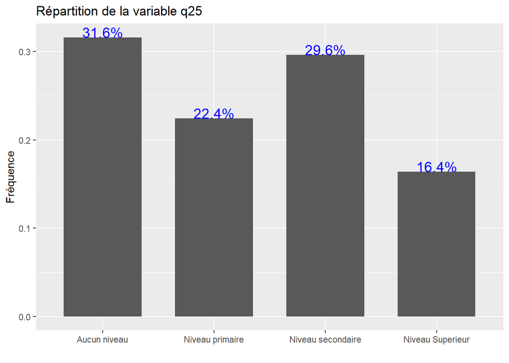

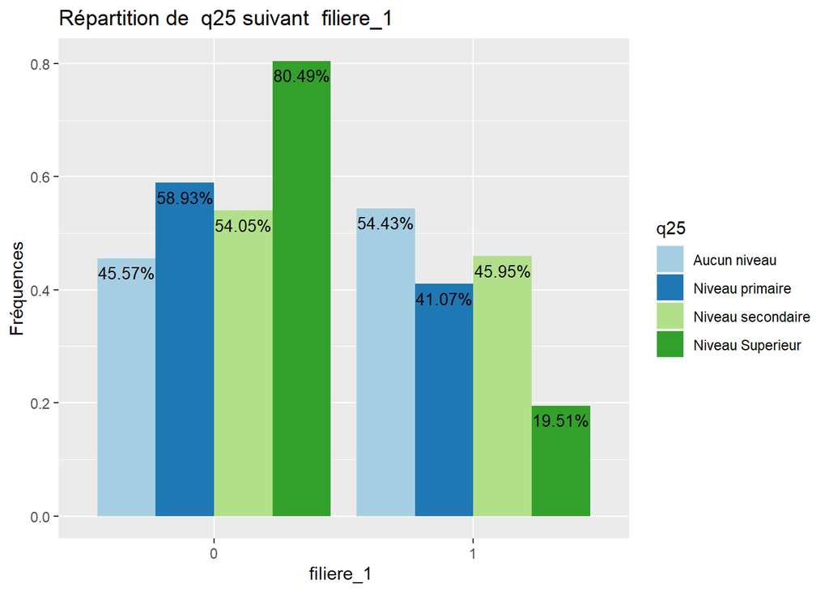

```
##   filiere_1 NBR_Aucun niveau FRQ_Aucun niveau NBR_Niveau primaire
## 1         1               43        0.5443038                  23
## 2         0               36        0.4556962                  33
##   FRQ_Niveau primaire NBR_Niveau secondaire FRQ_Niveau secondaire
## 1           0.4107143                    34             0.4594595
## 2           0.5892857                    40             0.5405405
##   NBR_Niveau Superieur FRQ_Niveau Superieur
## 1                    8             0.195122
## 2                   33             0.804878
```

```r
#Utilisation  de la fonction univarie()
univarie <- function(df, nom_var, nom_var_cible, ...) {

  # Vérification des noms de colonnes du data frame(df)
  stopifnot(is.data.frame(df)) #On utilise la fonction stopifnot pour verifier l'existence du data frame
  stopifnot(nom_var %in% colnames(df), nom_var_cible %in% colnames(df))

  result <- data.frame()

  #Analyse à appliquer pour une variable numérique
  if (is.numeric(df[, nom_var])){
    #Résumé statistique de la variable avec summary()
     result <- summary(df[nom_var], na.rm=T) #la fonction renvoie 5 valeurs : le minimum (Min.), le premier quartile (1st Qu.), la médiane (Median), la moyenne (Mean), le troisième quartile (3rd Qu.) et le maximum (Max)

     #Calcul de l'ecart-type avec la fonction sd()
     result <- rbind(result, paste("Ec-type.:", round(sd(df[,nom_var], na.rm=T), 2), sep = ""))

    # Réalisation de la boîte à moustâche avec la fonction boxplot()
    boxplot(df[, nom_var] ~ df[, nom_var_cible], ylim=c(min(df[nom_var]),max(df[nom_var])),
            xlab=paste("", nom_var_cible), ylab=paste("", nom_var),
            main = paste("Boxplot de ", nom_var, "suivant ", nom_var_cible))
  }

  #Analyse à appliquer pour une variable catégorique
  if (is.factor(df[, nom_var]) | is.character(df[, nom_var])){
    #création d'un dataframe pour les stats de la variable selon la cible
    result <- data.frame(matrix(unlist(unique(df[, nom_var_cible])), nrow=length(unique(df[, nom_var_cible])),
                                  byrow=TRUE),stringsAsFactors=FALSE)
    colnames(result)[1] <- nom_var_cible

     modalite_cible <- unique(df[, nom_var_cible])
     modalite_var <- unique(df[, nom_var])
     for (i in 1:length(modalite_var)){
       nbr = c()
       frq = c()
       f <- df %>% filter(df[, nom_var]==modalite_var[i])
       for (j in 1:length(modalite_cible)){
         filtre <- df %>% filter(df[, nom_var_cible]==modalite_cible[j] & df[, nom_var]==modalite_var[i])
         nbr[length(nbr)+1] = nrow(filtre)
         frq[length(frq)+1] = nrow(filtre)/nrow(f)
       }
       stat<-data.frame(matrix(c(nbr,frq),length(modalite_cible), 2))
      names(stat)<-c(paste("NBR", modalite_var[i], sep = "_"), paste("FRQ", modalite_var[i], sep = "_"))

      result<-cbind(result,stat)

     }
    # Réalisation Diagramme à barre avec ggplot()
     #barplot(table(df[nom_var]))
     colf <- data.frame(table(df[nom_var]))
     per_data <- df %>% count(df[, nom_var]) %>% mutate(per=n/sum(n), per_label = paste0(round(per*100, 2), "%"))
    ggbarplot <- ggplot(per_data, aes(x=colf[, 1], y=per))+
      geom_bar(stat = "identity", width = 0.7)+
      geom_text(aes(label= per_label), vjust=0, color = "blue", size=5)+
      labs(x="", y = "Fréquence", title = paste("Répartition de la variable", nom_var, sep = " "))

    # Réalisation Diagramme à barre de la variable suivant la cible


    perdata <- df %>% group_by(df[, nom_var], df[, nom_var_cible]) %>%
      tally() %>% mutate(frequence=n/sum(n), per_label = paste0(round(frequence*100, 2), "%"))


      plotcible <-  ggplot(data=perdata, aes(x=factor(perdata[[2]]), y=frequence, fill=perdata[[1]])) +
      geom_bar(stat="identity", position=position_dodge())+
      geom_text(aes(label=per_label), vjust=1.6, color="black",
                position = position_dodge(0.9), size=3.5)+
      scale_fill_brewer(palette="Paired")+
      labs(x=paste(nom_var_cible,""),y="Fréquences", fill = paste0(nom_var, ""),
           title =paste("Répartition de ", nom_var ,"suivant ",nom_var_cible))+
      theme_gray()


    print(ggbarplot)
    print(plotcible)

  }




  # sortie
  return(result)
}

#Utilisation de la fonction univarie()
univarie(projet, "q25", "filiere_1")
```

```r
library(questionr)
#Implémentation de la fonction bivarie()
bivarie <- function(table_df, nom_vars, nom_var_quali, ...) {
  #Vérification du dataFrame
  stopifnot(is.data.frame(table_df))
  # Vérification de la taille de nom_vars_quanti et des noms de colonnes de table_df
  stopifnot(length(nom_vars) == 2,
            all(nom_vars %in% colnames(table_df)))

  # Vérification de nom_var_quali
  stopifnot(nom_var_quali %in% colnames(table_df))

  # on identifie les modalités et leur nombre
    modalites <- unique(table_df[, nom_var_quali])

  n.modalites <- length(modalites)

  # on prépare la matrice contenant les effectifs et les coeff. de corrélation par modalité
  res <- matrix(0, n.modalites, 2)

  resultbivarie <- data.frame()

  #Entre deux variables quantitatives
  if (is.numeric(table_df[, nom_vars[1]]) & is.numeric(table_df[, nom_vars[2]])){
    for(i in 1:n.modalites) {
      # on identifie les indices associés à la modalité k
      mod <- which(table_df[, nom_var_quali] == modalites[i])
      # on remplit les effectifs
      res[i, 1] <- length(mod)
      # on calcule le coefficient de corrélation
      res[i, 2] <- cor(table_df[mod, nom_vars[1]],
                       table_df[mod, nom_vars[2]])
      # on dessine le nuage de points correspondants
      plot(table_df[mod, nom_vars[1]],
           table_df[mod, nom_vars[2]],
           main = paste("Modalité", modalites[i],
                        "(r =", round(res[i, 2], 2),")"), xlab = paste("", nom_vars[1]), ylab = paste("", nom_vars[2]),
           xlim = range(table_df[, nom_vars[1]]),
           ylim = range(table_df[, nom_vars[2]]),
           ...)
    }
    resultbivarie <- data.frame(mod = modalites, n = res[, 1], cor = res[, 2])
  }

  #Entre deux variables qualitatives
  if ((is.factor(table_df[, nom_vars[1]]) | is.character(table_df[, nom_vars[1]])) & (is.factor(table_df[, nom_vars[2]]) |
                                                                                      is.character(table_df[, nom_vars[2]]))){

    #création d'un dataframe pour les stats
    resultbivarie <- data.frame(matrix(unlist(unique(table_df[, nom_vars[2]])), nrow=length(unique(table_df[, nom_vars[2]])), byrow=TRUE),stringsAsFactors=FALSE)

    colnames(resultbivarie)[1] <- nom_vars[2]

     modalite_cible <- unique(table_df[, nom_vars[2]])
     modalite_var <- unique(table_df[, nom_vars[1]])
     for (i in 1:length(modalite_var)){
       nbr = c()
       frq = c()
       f <- table_df %>% filter(table_df[, nom_vars[1]]==modalite_var[i])
       for (j in 1:length(modalite_cible)){
         filtre <- table_df %>% filter(table_df[, nom_vars[2]]==modalite_cible[j] & table_df[, nom_vars[1]]==modalite_var[i])
         nbr[length(nbr)+1] = nrow(filtre)
         frq[length(frq)+1] = nrow(filtre)/nrow(f)
       }
       stat<-data.frame(matrix(c(nbr,frq),length(modalite_cible), 2))
      names(stat)<-c(paste("NBR", modalite_var[i], sep = "_"), paste("FRQ", modalite_var[i], sep = "_"))

      resultbivarie<-cbind(resultbivarie,stat)

     }


    #Création d'un barplot
    perdata <- table_df %>% group_by(table_df[, nom_vars[1]], table_df[, nom_vars[2]]) %>%
      tally() %>% mutate(frequence=n/sum(n), per_label = paste0(round(frequence*100, 2), "%"))


      plotcible <-  ggplot(data=perdata, aes(x=factor(perdata[[2]]), y=frequence, fill=perdata[[1]])) +
      geom_bar(stat="identity", position=position_dodge())+
      geom_text(aes(label=per_label), vjust=1.6, color="black",
                position = position_dodge(0.9), size=3.5)+
      scale_fill_brewer(palette="Paired")+
      labs(x=paste(nom_vars[2],""),y="Fréquences", fill = paste0(nom_vars[1], ""),
           title =paste("Répartition de ", nom_vars[1] ,"suivant ",nom_vars[2]))+
      theme_gray()

    print(plotcible)
  }

  #Entre une variable quantitative et une variable qualitative
  else {
    if (is.numeric(table_df[, nom_vars[1]])){
       boxplot(table_df[, nom_vars[1]] ~ table_df[, nom_vars[2]],
            xlab=paste("", nom_vars[2]), ylab=paste("", nom_vars[1]),
            main = paste("Boxplot de ", nom_vars[1], "suivant ", nom_vars[2]))
    }
    else {
      boxplot(table_df[, nom_vars[2]] ~ table_df[, nom_vars[1]],
            xlab=paste("", nom_vars[1]), ylab=paste("", nom_vars[2]),
            main = paste("Boxplot de ", nom_vars[2], "suivant ", nom_vars[1]))
    }

  }

  # on retourne le résultat sous forme de data.frame
  return(resultbivarie)
}

#Application avec la base de données iris
#bivarie(projet, c("sexe","q25"), "filiere_1")
```

**3 Un peu de cartographie**

- Transformer le **data.frame** en données géographiques dont l’objet sera nommé **projet_map**

```r
library(ggplot2) #chargement du package gglot2 pour les graphique
library(ggspatial)
library(sf) # pour les objets spatials
#Convertir le format sp au format sf
projet_map = st_as_sf(x = projet, coords = c("gps_menlongitude", "gps_menlatitude"), crs = 6622)
projet_map
```

```
## Simple feature collection with 250 features and 31 fields
## Geometry type: POINT
## Dimension:     XY
## Bounding box:  xmin: -17.43384 ymin: 12.39087 xmax: -14.08056 ymax: 16.6512
## Projected CRS: NAD83(CSRS) / Quebec Lambert
## First 10 features:
##                                          key          q1         q2   q23 q24
## 1  uuid:68bff42b-1228-4c66-9bcc-e6d312d9fea6    Diourbel     Bambey Femme  65
## 2  uuid:d70b3c7e-3ca0-4358-bc59-3f7f6baf55e9       Thiès      Mbour Femme  52
## 3  uuid:0ac18b64-7d85-4bb9-a842-698ac79909af       Thiès      Mbour Femme  65
## 4  uuid:c52cf5e4-8c28-4e65-998b-3fe2a971a1a3       Thiès      Mbour Femme  38
## 5  uuid:ac177870-001c-4ada-8747-c22ffe4e4596  Ziguinchor    Bignona Homme  40
## 6  uuid:578097cf-9af7-46e6-8992-d9079b14c342  Ziguinchor   Oussouye Femme  43
## 7  uuid:c3065ed7-c16a-4578-b8fa-e09ffc7bced7       Thiès      Thiès Femme  53
## 8  uuid:74e608ca-a37e-47e3-8b22-e1e4bd51fa44  Ziguinchor Ziguinchor Homme  33
```

[output cut: 57 more lines]

- Trouver le code qui permet d’avoir la carte ci-dessous

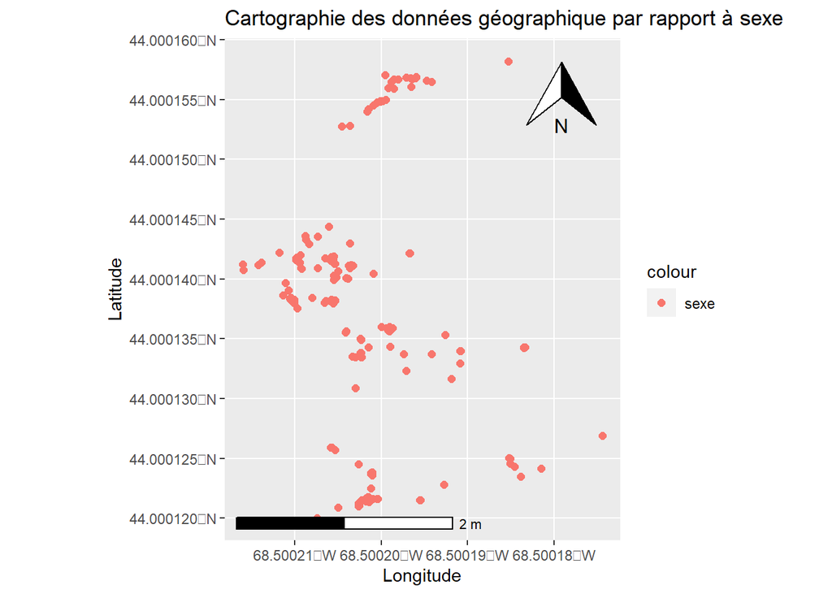

```r
#   Donner des axes, titre, légende, orientation, échelle à la carte ci-dessus
ggplot(projet_map) +
  aes(colour = "sexe") +
  geom_sf(size = 2L) +
  scale_color_hue(direction = 1) +
  labs(
    x = "Longitude",
    y = "Latitude",
    title = "Cartographie des données géographique par rapport à sexe"
  ) +
  annotation_scale(location = "bl", width_hint = 0.6)+
  annotation_north_arrow(location = "tr", which_north = "true",
                         pad_x = unit(0.2, "in"), pad_y = unit(0.2, "in"))+
  theme_gray()
```

**Importer et afficher les différentes cartes suivant les niveaux décrits ci-dessus**

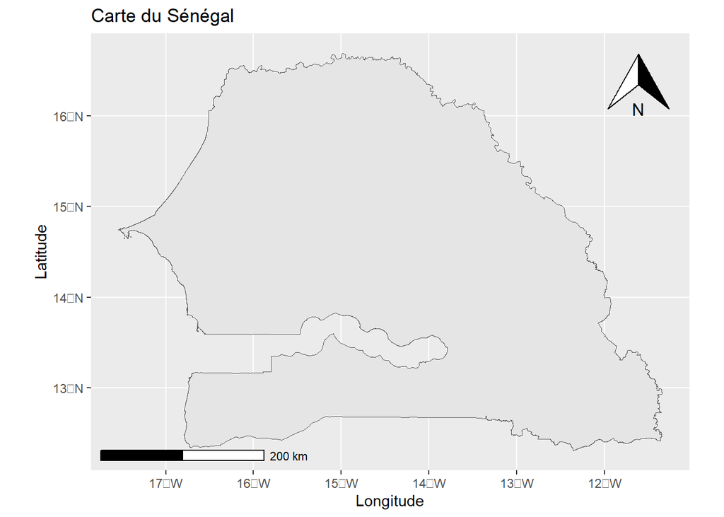

```r
SEN_adm0 <- st_read("C:/Users/DELL/Desktop/R_M1/SEN_adm/SEN_adm0.shp",quiet = T)
ggplot(st_geometry(SEN_adm0)) + geom_sf()+
  labs(
    x = "Longitude",
    y = "Latitude",
    title = "Carte du Sénégal"
  ) +
  annotation_scale(location = "bl", width_hint = 0.3)+
  annotation_north_arrow(location = "tr", which_north = "true",
                         pad_x = unit(0.2, "in"), pad_y = unit(0.2, "in"))+
  theme_gray()
```

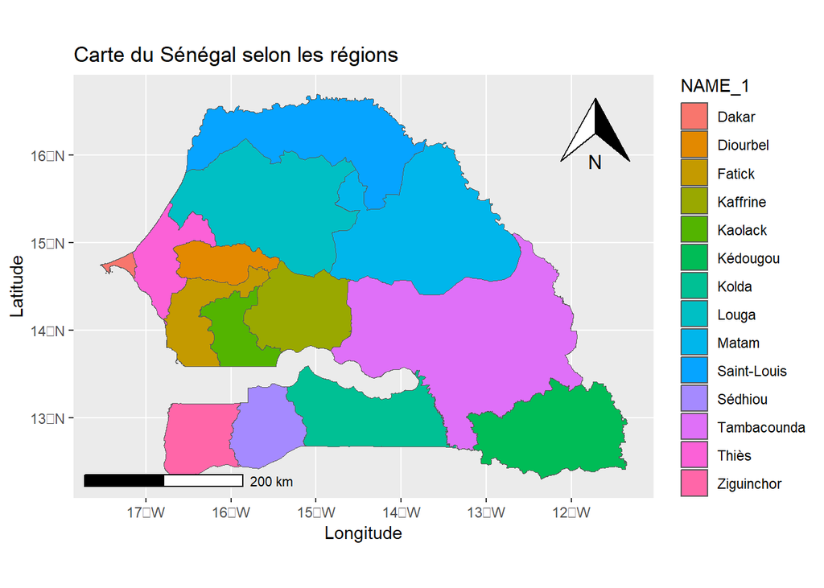

```r
SEN_adm1 <- st_read("C:/Users/DELL/Desktop/R_M1/SEN_adm/SEN_adm1.shp",quiet = T)

ggplot(SEN_adm1) +
  aes(fill = NAME_1) +
  geom_sf(size = 1.2) +
  scale_fill_hue(direction = 1) +
  labs(
    x = "Longitude",
    y = "Latitude",
    title = "Carte du Sénégal selon les régions"
  ) +
   annotation_scale(location = "bl", width_hint = 0.3)+
  annotation_north_arrow(location = "tr", which_north = "true",
                         pad_x = unit(0.2, "in"), pad_y = unit(0.2, "in"))+
  theme_gray()
```

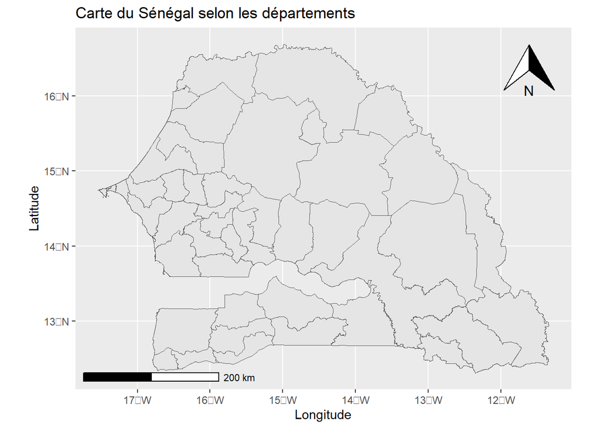

```r
SEN_adm2 <- st_read("C:/Users/DELL/Desktop/R_M1/SEN_adm/SEN_adm2.shp",quiet = T)
ggplot(st_geometry(SEN_adm2)) + geom_sf()+
  labs(
    x = "Longitude",
    y = "Latitude",
    title = "Carte du Sénégal selon les départements"
  ) +
   annotation_scale(location = "bl", width_hint = 0.3)+
  annotation_north_arrow(location = "tr", which_north = "true",
                         pad_x = unit(0.2, "in"), pad_y = unit(0.2, "in"))+
  theme_gray()
```

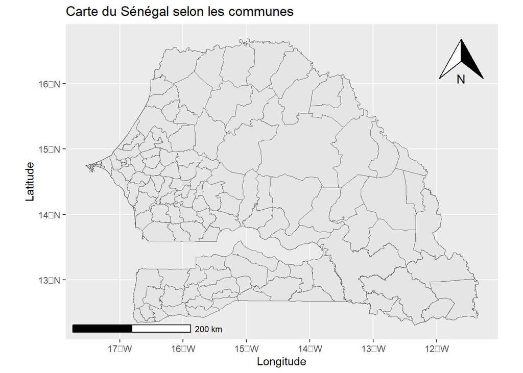

```r
SEN_adm3 <- st_read("C:/Users/DELL/Desktop/R_M1/SEN_adm/SEN_adm3.shp",quiet = T)
ggplot(st_geometry(SEN_adm3)) + geom_sf()+
  labs(
    x = "Longitude",
    y = "Latitude",
    title = "Carte du Sénégal selon les communes"
  ) +
  annotation_scale(location = "bl", width_hint = 0.3)+
  annotation_north_arrow(location = "tr", which_north = "true",
                         pad_x = unit(0.2, "in"), pad_y = unit(0.2, "in"))+
  theme_gray()
```

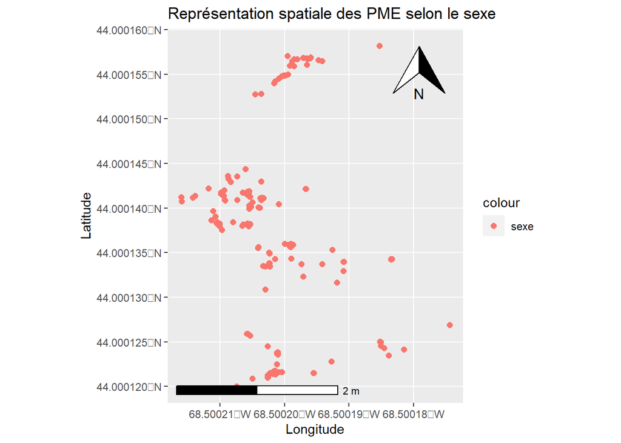

```r
ggplot(projet_map) +
  aes(colour = "sexe") +
  geom_sf(size = 2L) +
  scale_color_hue(direction = 1) +
  labs(
    x = "Longitude",
    y = "Latitude",
    title = "Représentation spatiale des PME selon le sexe"
  ) +
  annotation_scale(location = "bl", width_hint = 0.6)+
  annotation_north_arrow(location = "tr", which_north = "true",
                         pad_x = unit(0.2, "in"), pad_y = unit(0.2, "in"))+
  theme_gray()
```

**Représentation spatiale des PME suivant le niveau d’instruction**

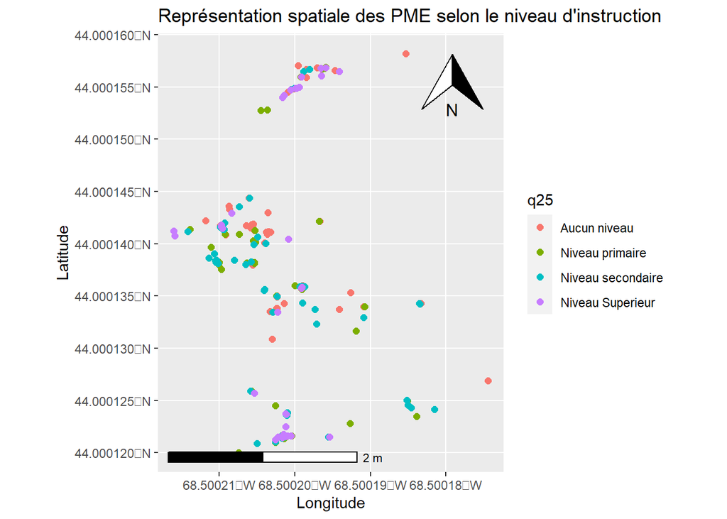

```r
ggplot(projet_map) +
  aes(colour = q25) +
  geom_sf(size = 2L) +
  scale_color_hue(direction = 1) +
  labs(
    x = "Longitude",
    y = "Latitude",
    title = "Représentation spatiale des PME selon le niveau d'instruction"
  ) +
  annotation_scale(location = "bl", width_hint = 0.6)+
  annotation_north_arrow(location = "tr", which_north = "true",
                         pad_x = unit(0.2, "in"), pad_y = unit(0.2, "in"))+
  theme_gray()
```

**Représentation spatiale des PME suivant le statut juridique**

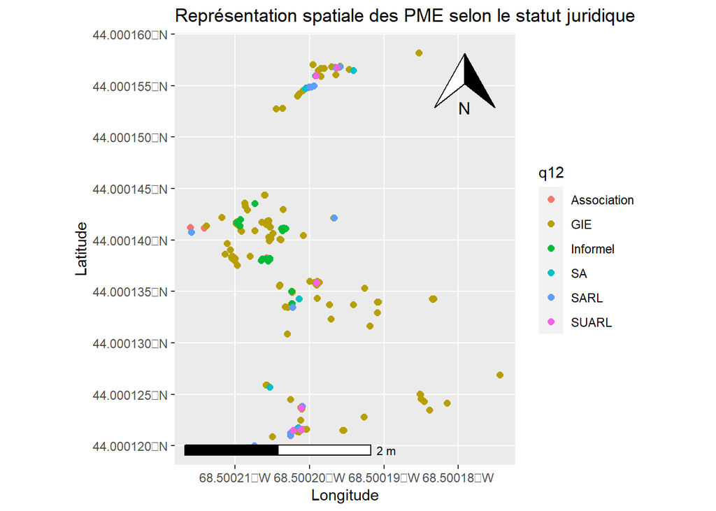

```r
ggplot(projet_map) +
  aes(colour = q12) +
  geom_sf(size = 2L) +
  scale_color_hue(direction = 1) +
  labs(
    x = "Longitude",
    y = "Latitude",
    title = "Représentation spatiale des PME selon le statut juridique"
  ) +
  annotation_scale(location = "bl", width_hint = 0.6)+
  annotation_north_arrow(location = "tr", which_north = "true",
                         pad_x = unit(0.2, "in"), pad_y = unit(0.2, "in"))+
  theme_gray()
```